# `Tps` and `fastTps`

## `Tps` and `Krig`

We return to `Tps`, but this time consider spatial data. The `Tps` estimate can be thought of as a special case of a spatial process estimate using a particular generalized covariance function. Because of this correspondence the `Tps` function is a wrapper that determines the polynomial order for the null space and then calls `Krig` with the radial basis generalized covariance `rad.cov`. The RBF is the reproducing kernel that generates the reproducing kernel Hilbert space in which the minimization problem is set. See Wahba’s *Spline Models for Observational Data*.

In this way `Tps` requires little extra coding beyond the `Krig` function itself, and in fact the returned list from `Tps` is a `Krig` object and so it is adapted to all the special functions developed for this object format. One downside is some confusion in the summary of the thin plate spline as a spatial process type estimator. For example, the summary refers to a covariance model and maximum likelihood estimates. This is not something usually reported with a spline fit! Similarly, `fastTps` is a convenient wrapper function that calls `mKrig` with the Wendland covariance function.

${\large{\mathbf{Basic \> Usage}}}$

> Tps(x, Y, m = NULL, p = NULL, lon.lat = FALSE)  
> fastTps(x, Y, m = NULL, p = NULL, aRange, lon.lat=FALSE, lambda=0)

${\large{\mathbf{Value}}}$

Both functions returns a list of class `Krig`. `m` determines the degree (`m-l`) of the polynomial function capturing the spatial drift/trend component of the model. The default is the value such that `2m-d` is greater than zero where `d` is the dimension of `x`. `p` is the polynomial power for Wendland radial basis functions. The default is `2m-d`. `aRange` is the tapering range that is passed to the Wendland compactly supported covariance. The covariance (i.e. the radial basis function) is zero beyond range `aRange`. The larger `aRange` is, the closer this model will approximate the standard thin plate spline.

Some care needs to exercised in specifying the taper range `aRange` and power `p` which describes the polynomial behavior of the Wendland at the origin. Note that unlike `Tps` the locations are not scaled to unit range and this can cause havoc in smoothing problems with variables in very different units. So rescaling the locations `x <- scale(x)` is a good idea for putting the variables on a common scale for smoothing. This function does have the potential to approximate estimates of `Tps` for very large spatial data sets. Also, the function `predictSurface.fastTps` has been made more efficient for the case of `k = 2` and `m = 2`.

## `ChicagoO3`

We return to the simple Chicago ozone measurement data, fitting models with different inputs for `df`. Remember `lambda` and `df` both represent the smoothness of the model on different scales. One of the great things about `Tps` is that the `predict` function is quite flexible: one can pass in a different `df` or `lambda` value to predict with. For example, the first call to `predict` in the example below evaluates the estimate at `lambda = 2` instead of the GCV estimate. It does this very efficiently from the `Krig` fit object.

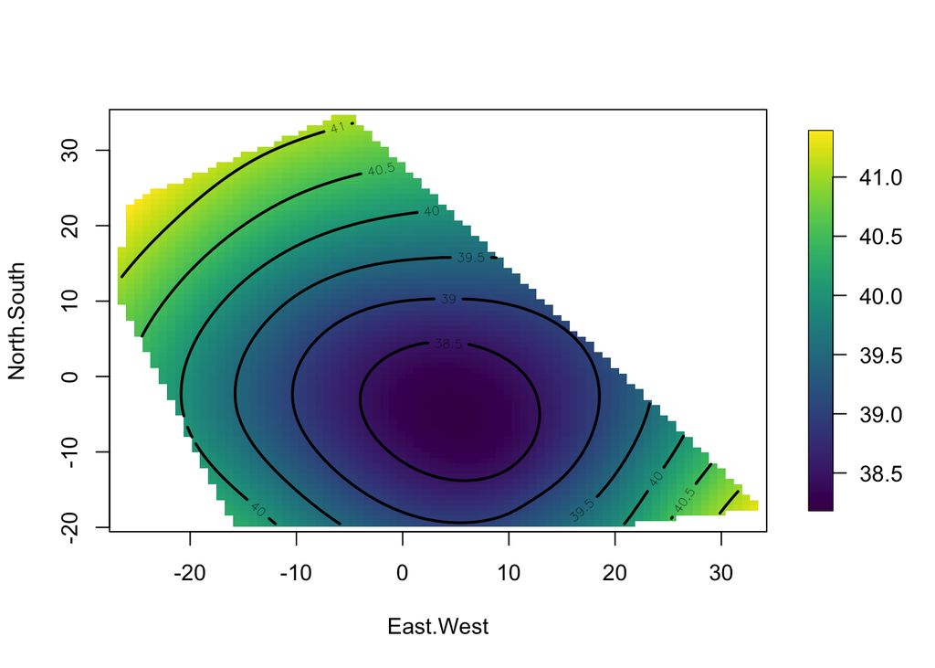

```r
fit <- Tps(ChicagoO3$x, ChicagoO3$y)
surface(fit)
```

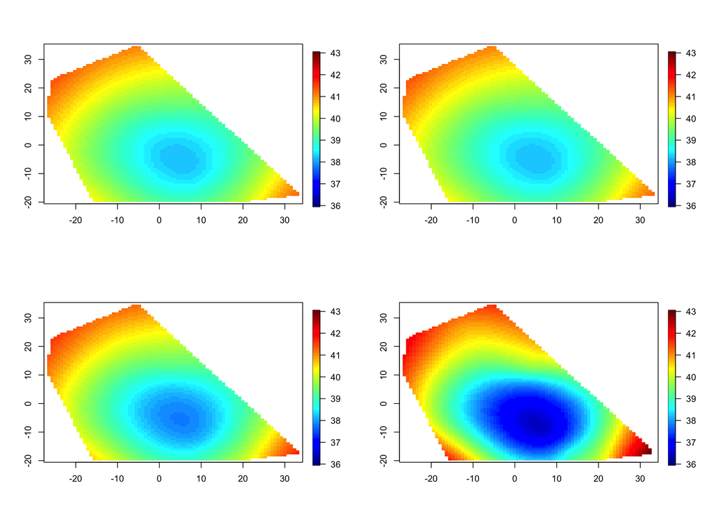

```r
look <- predict( fit, lambda=2.0)
look <- predict( fit, df=7.5)
set.panel(2,2)
for (i in seq(0,7.5,,4)){
  look<- predictSurface(fit, df=i)
  image.plot(look,smallplot= c(.88,.9,0.2,.8),zlim=c(36,43))
}
```

Even if `lambda` or `df` is specified in the `Tps` call, the GCV grid search is still performed and the information stored in the object. In the third panel of the diagnostic plot, the GCV function has a vertical line at the value of `df` given.

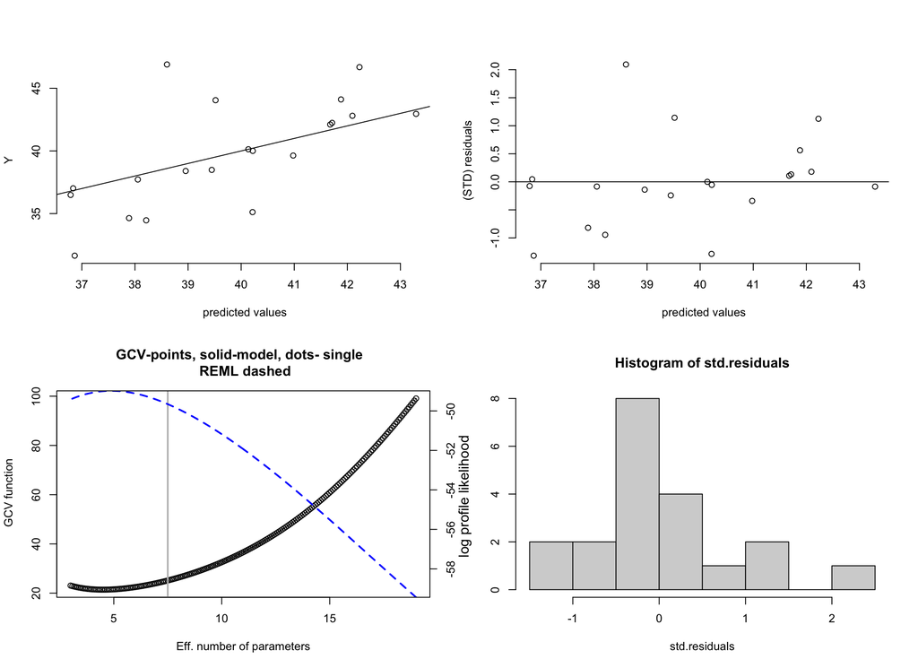

```r
fit1<- Tps(ChicagoO3$x, ChicagoO3$y,df=7.5)
set.panel(2,2)
plot(fit1)
```

The basic matrix decompositions are the same for both `fit` and `fit1` objects. `predict(fit1)` is the same as `predict(fit, df=7.5)`, and `predict(fit1, lambda=fit$lambda)` is equivalent to `predict(fit)`.

##`COmonthlyMet`

To be thorough, we include an example of using `Tps` with a `Z` covariate.

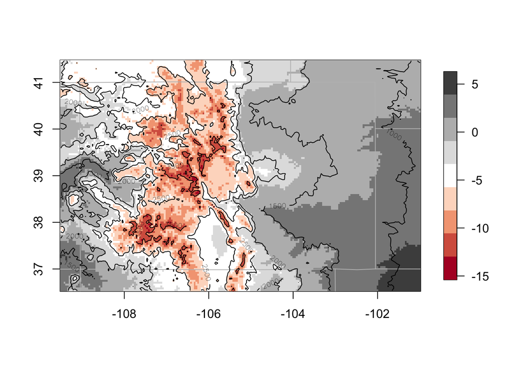

```r
data( COmonthlyMet)
obj <- Tps( CO.loc, CO.tmin.MAM.climate, Z= CO.elev)
out.p <-predictSurface(obj, grid.list=CO.Grid, ZGrid= CO.elevGrid,extrap=TRUE)
library(sp)
image.plot( out.p, col=brewer.pal(9,"RdGy"))
US(add=TRUE, col="grey")
contour( CO.elevGrid, add=TRUE, levels=c(1000,1500, 2000, 2500, 3500), col="black")
```

##`BD`

The models in `fields` can accept higher dimensional data sets than we have been using so far. The default when using `surface` with this type of data is to hold 3rd and 4th dimensions fixed at the median values.

```r
str(BD)
```

```
## 'data.frame':    89 obs. of  5 variables:
##  $ KCl  : num  30 30 20 50 25 10 40 15 50 10 ...
##  $ MgCl2: num  5 5 4 7 7 4 4 6 6 7 ...
##  $ KPO4 : num  25 25 20 20 30 25 20 45 35 25 ...
##  $ dNTP : num  625 625 1500 250 1500 1250 1250 1250 1500 1250 ...
##  $ lnya : num  12.9 12.67 9.17 9.87 9.88 ...
```

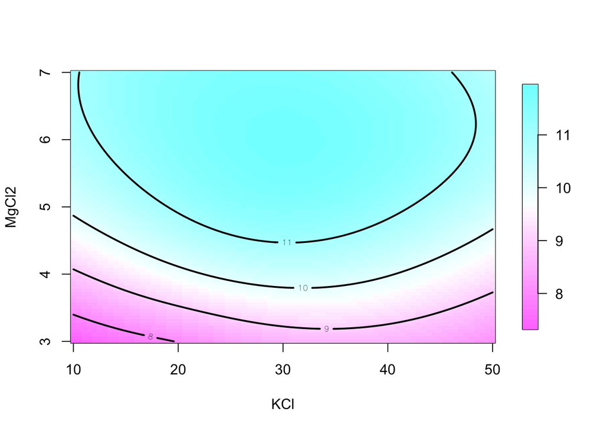

```r
fit <- Tps(BD[,1:4],BD$lnya,scale.type="range")
surface(fit,col=rev(cm.colors(50)))
```

##`fastTps` with several `lambda` values

The `fastTps` function is actually a wrapper for the `mKrig` function with the compactly supported Wendland covariance function. The taper range `aRange` and the the polynomial power for the Wendland rbf `p` must be chosen. The defaults are `aRange = 1` and `p = 2m-d` where `m` is chosen such that `p` is positive.

Both `Tps` and `fastTps` return a list of class `Krig` which includes fitted values, the predicted surface at the observations, and the residuals. The list also includes the values of the GCV grid search.

We start by showing how different `lambda` values affect the `fastTps` fit using the Rocky Mountain precipitation data.

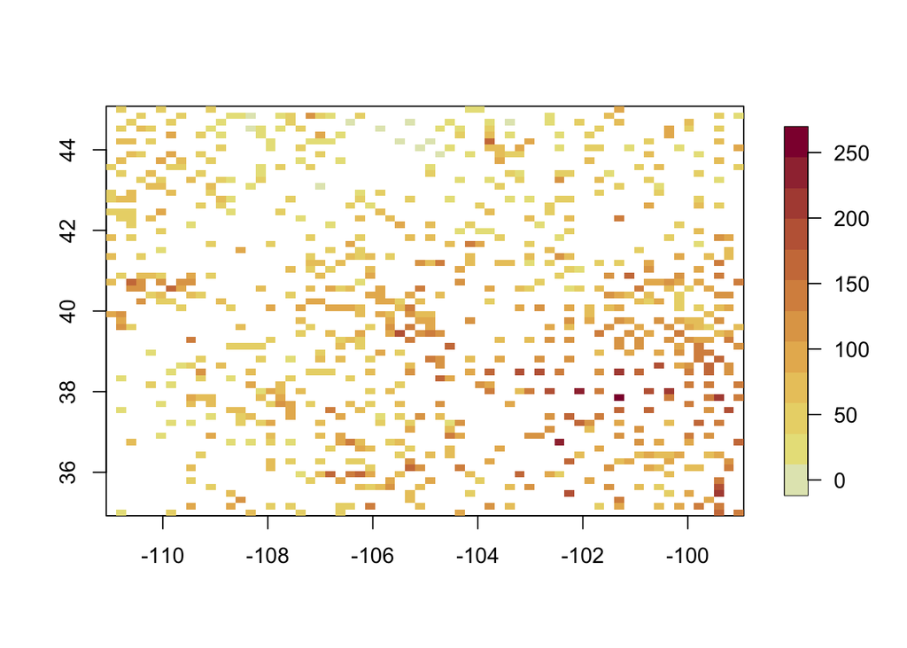

```r
hc <- rev(heat_hcl(12,c=c(80,30),l=c(30,90),power=c(1/5,1.5)))

quilt.plot(RMprecip$x,RMprecip$y,col=hc)
```

```r
fastTps( RMprecip$x,RMprecip$y,m=2,lambda= 1e-2, aRange=3.0) -> out1
fastTps( RMprecip$x,RMprecip$y,m=2,lambda= 1e-1, aRange=3.0) -> out2
fastTps( RMprecip$x,RMprecip$y,m=2,lambda= 1, aRange=3.0) -> out3
```

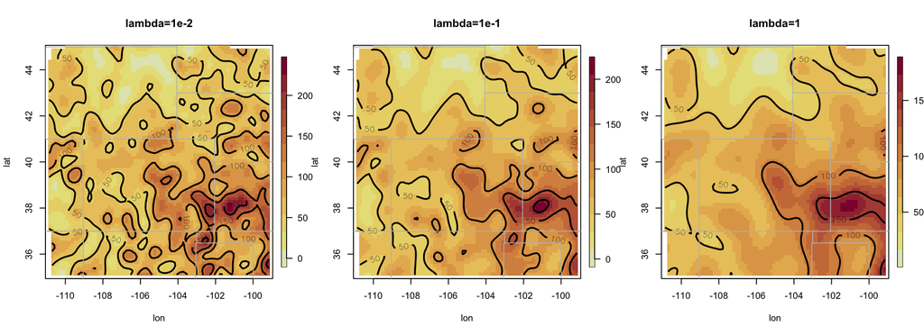

```r
set.panel(1,3)
surface(out1, main="lambda=1e-2",col=hc)
US( add=TRUE, col="grey")
surface(out2, main="lambda=1e-1",col=hc)
US( add=TRUE, col="grey")
surface(out3, main="lambda=1",col=hc)
US( add=TRUE, col="grey")
```

Note that setting `aRange` to 3 degrees is a very generous taper range. Use some trial `aRange` values with `rdist.nearest` to determine a a useful taper (see the examples in `mKrig`). Some empirical studies suggest that in the interpolation case in 2d, the taper should be large enough so there are about 20 non-zero nearest neighbors for every location.

```r
fastTps( RMprecip$x,RMprecip$y,m=2,lambda= 1e-2,lon.lat=TRUE, aRange=300) -> out4
out3$eff.df
out4$eff.df
```

[output not shown]

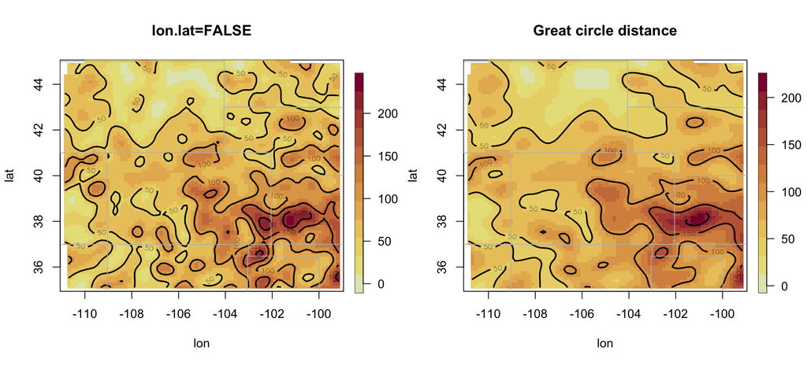

```r
set.panel(1,2)
surface(out1, main="lon.lat=FALSE",smallplot= c(.88,.9,0.2,.8),col=rev(heat_hcl(12,c=c(80,30),l=c(30,90),power=c(1/5,1.5))))
US( add=TRUE, col="grey")
surface(out4, main="Great circle distance",smallplot= c(.88,.9,0.2,.8),col=rev(heat_hcl(12,c=c(80,30),l=c(30,90),power=c(1/5,1.5))))
US( add=TRUE, col="grey")
```

##`sim.fastTps.approx` and `ozone2`

In this final example, we show how to use `sim.fastTps.approx`. We produce a local conditional simulation using the covariance from `fastTps`. The `sim.approx` methods evaluate the conditional surface on a grid and simulate the values of $h(x)$ off the grid using bilinear interpolation of the four nearest grid points. Because of this approximation it is important to choose the grid to be fine relative to the spacing of the observations. The advantage of this approximation is that one can consider conditional simulation for large grids beyond the size possible with exact methods. Here, the method for simulation is circulant embedding and so is restricted to stationary fields. The circulant embedding method is known to fail if the domain is small relative to the correlation range. The argument `gridExpansion` can be used to increase the size of the domain to make the algorithm work. `sim.fastTps.approx` is optimized for the approximate thin plate spline estimator in two dimensions and `k=2`. For efficiency, the ensemble prediction locations must be on a grid.

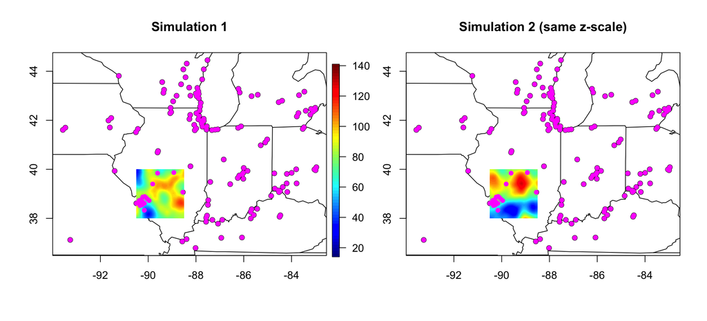

```r
data(ozone2)
y<- ozone2$y[16,]
good<- !is.na( y)
y<-y[good]
x<- ozone2$lon.lat[good,]
O3Obj<- fastTps( x,y, aRange=1.5 )
grid.list<- fields.x.to.grid( O3Obj$x, nx=100, ny=100)
O3Sim<- sim.mKrig.approx( O3Obj,predictionPointsList=grid.list,M=5)
# controlling the grids
xR<- range( x[,1], na.rm=TRUE)
yR<- range( x[,2], na.rm=TRUE)
simulationGridList<- list( x= seq(xR[1],xR[2],,400), y= seq( yR[1],yR[2], ,400))
# very fine localized prediction grid
O3GridList<- list( x= seq( -90.5,-88.5,,200), y= seq( 38,40,,200))
O3Sim<- sim.mKrig.approx( O3Obj, M=5, predictionPointsList=O3GridList, simulationGridList = simulationGridList)
set.panel(1,2)
plot( O3Obj$x, main="Simulation 1",xlab="",ylab="")
US( add=TRUE)
image.plot( as.surface( O3GridList,O3Sim$Ensemble[,2] ), add=TRUE,smallplot= c(.94,.96,0.2,.8),zlim=c(15,140))
points( O3Obj$x, pch=16, col="magenta")
plot( O3Obj$x, main="Simulation 2 (same z-scale)",xlab="",ylab="")
US( add=TRUE)
image( as.surface( O3GridList,O3Sim$Ensemble[,1] ), add=TRUE,zlim=c(15,140),col=tim.colors())
points( O3Obj$x, pch=16, col="magenta")
```